# Assignment03

Tejaswini Sengaonkar

2023-03-20

# Assignment 3

## Task 1: Generate data

To illustrate the idea of using sandwich estimator, we first generate a set of data with increased variances as the predictor.

Step 1.1: Run the following piece of code, with your student as seed.

```r
set.seed(507880432)
n <- 200
x <- rnorm(n)
residual_std <- exp(x)
y <- 1.5+3*x + residual_std*rnorm(n)
```

Step 1.2: Plot y vs. x and comment

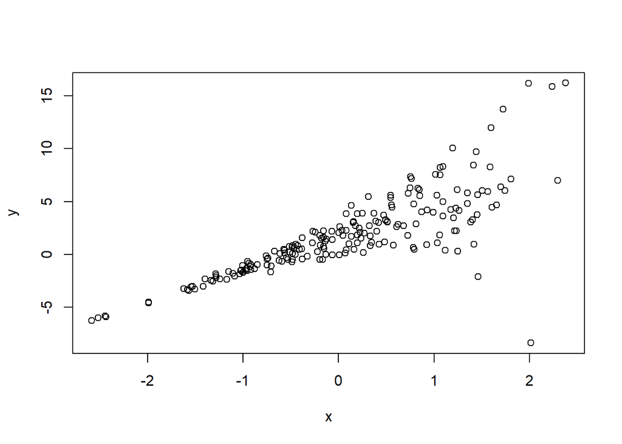

```r
plot(x,y)
```

## Task 2: Fit the linear regression model as usual

Step 2.1: Fit a linear regression model

Fit a linear regression model y~x and generate the model summary output.

```r
model <- lm(y ~ x)
summary(model)
```

```
##
## Call:
## lm(formula = y ~ x)
##
## Residuals:
##      Min       1Q   Median       3Q      Max
## -16.0316  -0.7437   0.0036   0.6171   8.6497
##
## Coefficients:
##             Estimate Std. Error t value Pr(>|t|)
## (Intercept)   1.5510     0.1615   9.601   <2e-16 ***
## x             3.0250     0.1591  19.007   <2e-16 ***
## ---
## Signif. codes:  0 '***' 0.001 '**' 0.01 '*' 0.05 '.' 0.1 ' ' 1
##
## Residual standard error: 2.277 on 198 degrees of freedom
## Multiple R-squared:  0.646,  Adjusted R-squared:  0.6442
## F-statistic: 361.3 on 1 and 198 DF,  p-value: < 2.2e-16
```

Step 2.2: Inference based on summary output What is the standard error of coefficient of X? What is the 95% confidence interval of the β1^ ? Interpret the p-value shown.

```r
round(summary(model)$coef["x","Std. Error"], 4) # Coefficient of x
```

```
## [1] 0.1591
```

```r
options(digits = 4)
summary(model)$coef["x" ,"Pr(>|t|)"] # p-value
```

```
## [1] 1.589e-46
```

```r
conf_int <- confint(model, "x", level = 0.95) # 95% confidence interval of β1^
conf_int # printing the value
```

```
##   2.5 % 97.5 %
## x 2.711  3.339
```

## Task 3: Sandwich estimator

Step 3.1: Calculate se(βi^) use sandwich estimator.

```r
# Load the package
library("sandwich")

# Using sandwich estimator.
sandwich_se<- sqrt(diag(vcovHC(model,type = 'HC')))

sandwich_se
```

```
## (Intercept)           x
##      0.1425      0.2451
```

Step 3.2: Inference Use the sandwich standard error for the coefficient of X to calculate the 95% confidence interval and p-value for β1.

```r
coef(model) - qt(0.975,model$df.residual)*sandwich_se #interpretation
```

```
## (Intercept)           x
##       1.270       2.542
```

```r
t_stat<-coef(model)/sandwich_se # t-statistic calculation using sandwich estimate.

p_val<- 2*(1-pt(t_stat,df=2,lower.tail = TRUE))

p_val
```

```
## (Intercept)           x
##    0.008335    0.006501
```

## Task 4: Comparison and Comment

What can you observe from comparing the two sets of inference results above?

When we compare values of p-values `(summary(model)$coef["x" ,"Pr(>|t|)"] )` to `p_val` we observe the p_value which is obtained using sandwich estimator is larger than previously obtained p-value. The same can be said for standard error.